# Data Mining Course Python(Jupyter Notebook) Task

### Task

Select one dataset from the UCI Repository, https://archive.ics.uci.edu/ml/datasets.php for the classification task. Realize the preprocessing, then use the Naive Bayes classifier, k-Nearest Neighbors and a decision tree. Compare the quality of classification with the use of 10-fold cross-validation. Prepare the full report in pdf. Add your own comments and conclusions. Do everything in Python.

- D = decision attribute (D) with values 0 (unhappy) and 1 (happy)
- X1 = the availability of information about the city services
- X2 = the cost of housing
- X3 = the overall quality of public schools
- X4 = your trust in the local police
- X5 = the maintenance of streets and sidewalks
- X6 = the availability of social community events

Attributes X1 to X6 have values 1 to 5.

```python
# Loads libraries
import numpy as np
import pandas as pd
```

```python
#data is stored as .xlsx format
data=pd.read_excel(r'C:\Users\emrul\SomervilleHappinessSurvey2015.xlsx')
data
```

|  | D | X1 | X2 | X3 | X4 | X5 | X6 |
| --- | --- | --- | --- | --- | --- | --- | --- |
| 0 | 0 | 3 | 3 | 3 | 4 | 2 | 4 |
| 1 | 0 | 3 | 2 | 3 | 5 | 4 | 3 |
| 2 | 1 | 5 | 3 | 3 | 3 | 3 | 5 |
| 3 | 0 | 5 | 4 | 3 | 3 | 3 | 5 |
| 4 | 0 | 5 | 4 | 3 | 3 | 3 | 5 |
| ... | ... | ... | ... | ... | ... | ... | ... |
| 138 | 0 | 5 | 3 | 3 | 1 | 3 | 5 |
| 139 | 1 | 5 | 2 | 3 | 4 | 2 | 5 |
| 140 | 1 | 5 | 3 | 3 | 4 | 4 | 5 |
| 141 | 0 | 4 | 3 | 3 | 4 | 4 | 5 |
| 142 | 0 | 5 | 3 | 2 | 5 | 5 | 5 |

143 rows × 7 columns

```python
# dataframe.info() shows column and datatype names.
data.info()
```

```
<class 'pandas.core.frame.DataFrame'>
RangeIndex: 143 entries, 0 to 142
Data columns (total 7 columns):
 #   Column  Non-Null Count  Dtype
---  ------  --------------  -----
 0   D       143 non-null    int64
 1   X1      143 non-null    int64
 2   X2      143 non-null    int64
 3   X3      143 non-null    int64
 4   X4      143 non-null    int64
 5   X5      143 non-null    int64
 6   X6      143 non-null    int64
dtypes: int64(7)
memory usage: 7.9 KB
```

```python
# This method shows number of rows and columns
data.shape
```

```
(143, 7)
```

```python
#With this method, you can see the statistics of all numerical columns.
data.describe()
```

|  | D | X1 | X2 | X3 | X4 | X5 | X6 |
| --- | --- | --- | --- | --- | --- | --- | --- |
| count | 143.000000 | 143.000000 | 143.000000 | 143.000000 | 143.000000 | 143.000000 | 143.000000 |
| mean | 0.538462 | 4.314685 | 2.538462 | 3.265734 | 3.699301 | 3.615385 | 4.216783 |
| std | 0.500271 | 0.799820 | 1.118155 | 0.992586 | 0.888383 | 1.131639 | 0.848693 |
| min | 0.000000 | 1.000000 | 1.000000 | 1.000000 | 1.000000 | 1.000000 | 1.000000 |
| 25% | 0.000000 | 4.000000 | 2.000000 | 3.000000 | 3.000000 | 3.000000 | 4.000000 |
| 50% | 1.000000 | 5.000000 | 3.000000 | 3.000000 | 4.000000 | 4.000000 | 4.000000 |
| 75% | 1.000000 | 5.000000 | 3.000000 | 4.000000 | 4.000000 | 4.000000 | 5.000000 |
| max | 1.000000 | 5.000000 | 5.000000 | 5.000000 | 5.000000 | 5.000000 | 5.000000 |

```python
# This method presents first x object in the dataframe.
data.head()
```

|  | D | X1 | X2 | X3 | X4 | X5 | X6 |
| --- | --- | --- | --- | --- | --- | --- | --- |
| 0 | 0 | 3 | 3 | 3 | 4 | 2 | 4 |
| 1 | 0 | 3 | 2 | 3 | 5 | 4 | 3 |
| 2 | 1 | 5 | 3 | 3 | 3 | 3 | 5 |
| 3 | 0 | 5 | 4 | 3 | 3 | 3 | 5 |
| 4 | 0 | 5 | 4 | 3 | 3 | 3 | 5 |

```python
# This method presents the last x objects in the dataframe
data.tail()
```

|  | D | X1 | X2 | X3 | X4 | X5 | X6 |
| --- | --- | --- | --- | --- | --- | --- | --- |
| 138 | 0 | 5 | 3 | 3 | 1 | 3 | 5 |
| 139 | 1 | 5 | 2 | 3 | 4 | 2 | 5 |
| 140 | 1 | 5 | 3 | 3 | 4 | 4 | 5 |
| 141 | 0 | 4 | 3 | 3 | 4 | 4 | 5 |
| 142 | 0 | 5 | 3 | 2 | 5 | 5 | 5 |

### Missing Values

Even though this dataset doesn't have missing values. Dealing with them could be good. And imputation/assigning values approach would be helpful when the missing data is dispersed in different in observation.

```python
#replacing questionmarks with np.nan
data=data.replace(to_replace='?', value=np.nan)
```

```python
#replacing with mode with respect to decision class
import random
def repl(data):
    for i in np.arange(data.shape[0]):
        for j in np.arange(data.shape[1]-1):
            if pd.isnull(data.iloc[i,j])== True:
                b=data.iloc[i,-1]
                c=[]
                for k in np.arange(data.shape[0]):
                    if data.iloc[k,-1]==b:
                        if pd.isnull(data.iloc[k,j])==False:
                            c.append(data.iloc[k,j])
                if len(c)!=0:
                    values, counts = np.unique(c, return_counts=True)
                    max_count_index = np.argmax(counts)
                    c=values[max_count_index]
                    data.iloc[i,j]=c
                else:
                    data.iloc[i,j]=random.choice(data.iloc[:,j].mode())
    return data
```

```python
data=repl(data)
data
```

|  | D | X1 | X2 | X3 | X4 | X5 | X6 |
| --- | --- | --- | --- | --- | --- | --- | --- |
| 0 | 0 | 3 | 3 | 3 | 4 | 2 | 4 |
| 1 | 0 | 3 | 2 | 3 | 5 | 4 | 3 |
| 2 | 1 | 5 | 3 | 3 | 3 | 3 | 5 |
| 3 | 0 | 5 | 4 | 3 | 3 | 3 | 5 |
| 4 | 0 | 5 | 4 | 3 | 3 | 3 | 5 |
| ... | ... | ... | ... | ... | ... | ... | ... |
| 138 | 0 | 5 | 3 | 3 | 1 | 3 | 5 |
| 139 | 1 | 5 | 2 | 3 | 4 | 2 | 5 |
| 140 | 1 | 5 | 3 | 3 | 4 | 4 | 5 |
| 141 | 0 | 4 | 3 | 3 | 4 | 4 | 5 |
| 142 | 0 | 5 | 3 | 2 | 5 | 5 | 5 |

143 rows × 7 columns

```python
#Python has the preprocessing library in sklearn that contains the normalize function to normalize the data.

# normalising data numerical data sets using min-max
def norm(data):
    for column in data.columns:
        if isinstance(data[column][0],str)==False and column != 'D':
            data[column]=(data[column]-data[column].min())/(data[column].max()-data[column].min())
    return data
```

```python
data=norm(data)
data
```

|  | D | X1 | X2 | X3 | X4 | X5 | X6 |
| --- | --- | --- | --- | --- | --- | --- | --- |
| 0 | 0 | 0.50 | 0.50 | 0.50 | 0.75 | 0.25 | 0.75 |
| 1 | 0 | 0.50 | 0.25 | 0.50 | 1.00 | 0.75 | 0.50 |
| 2 | 1 | 1.00 | 0.50 | 0.50 | 0.50 | 0.50 | 1.00 |
| 3 | 0 | 1.00 | 0.75 | 0.50 | 0.50 | 0.50 | 1.00 |
| 4 | 0 | 1.00 | 0.75 | 0.50 | 0.50 | 0.50 | 1.00 |
| ... | ... | ... | ... | ... | ... | ... | ... |
| 138 | 0 | 1.00 | 0.50 | 0.50 | 0.00 | 0.50 | 1.00 |
| 139 | 1 | 1.00 | 0.25 | 0.50 | 0.75 | 0.25 | 1.00 |
| 140 | 1 | 1.00 | 0.50 | 0.50 | 0.75 | 0.75 | 1.00 |
| 141 | 0 | 0.75 | 0.50 | 0.50 | 0.75 | 0.75 | 1.00 |
| 142 | 0 | 1.00 | 0.50 | 0.25 | 1.00 | 1.00 | 1.00 |

143 rows × 7 columns

### Correlation

Attributes might be dependent on each other, in that case it would be redundant to have both variables in the model. For preparation step involves removing those variables, so that will reduce the effect of other variables on the model to determine how variables are dependent on each other correlation is calculated.

```python
def co(data):
    for column in data.columns:
        if isinstance(data[column][0],str)==True:
            data.drop([column],axis=1)
    cor=data.corr()
    return cor
```

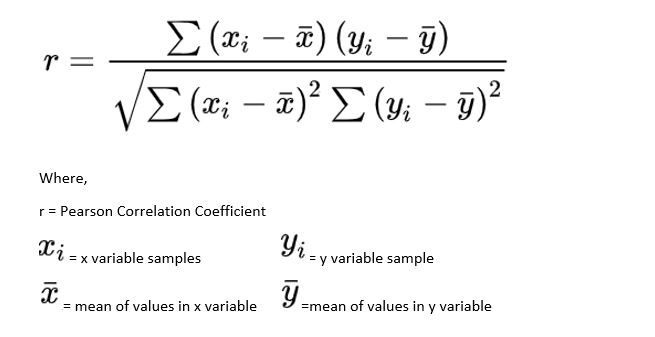

```python
co(data)
```

|  | D | X1 | X2 | X3 | X4 | X5 | X6 |
| --- | --- | --- | --- | --- | --- | --- | --- |
| D | 1.000000 | 0.312740 | 0.019368 | 0.163639 | 0.113356 | 0.206685 | 0.220729 |
| X1 | 0.312740 | 1.000000 | 0.092676 | 0.301971 | 0.104378 | 0.399203 | 0.417521 |
| X2 | 0.019368 | 0.092676 | 1.000000 | 0.181081 | 0.107432 | -0.002141 | 0.024546 |
| X3 | 0.163639 | 0.301971 | 0.181081 | 1.000000 | 0.298898 | 0.329874 | 0.207006 |
| X4 | 0.113356 | 0.104378 | 0.107432 | 0.298898 | 1.000000 | 0.269420 | 0.199151 |
| X5 | 0.206685 | 0.399203 | -0.002141 | 0.329874 | 0.269420 | 1.000000 | 0.307402 |
| X6 | 0.220729 | 0.417521 | 0.024546 | 0.207006 | 0.199151 | 0.307402 | 1.000000 |

### Outliers

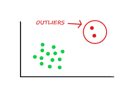

An Outlier is an observation that lies apart from other values in the data. Outliers can be detected by visualisation.

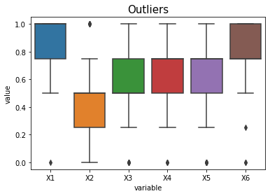

```python
import matplotlib.pyplot as plt
import seaborn as sns
bf = pd.DataFrame(data, columns = ['X1','X2','X3','X4', 'X5', 'X6'])
sns.boxplot(x="variable", y="value", data=pd.melt(bf))
plt.title('Outliers', fontsize=15)

#Outliers for all columns can be seen below:
```

#### Calculate upper and lower limits with Zscore:

A normal distribution is shown below and it is estimated that:

- 68% of the data points lie between +/- 1 standard deviation.
- 95% of the data points lie between +/- 2 standard deviation
- 99.7% of the data points lie between +/- 3 standard deviation

In this example there is assumption that any value beyond this 99.7 is an outlier.

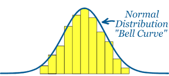

```python
#Calculating Zscore for all conditional attributes and displaying it.
from scipy.stats import zscore
cols = list(data.columns)
cols.remove('D')
data[cols]
```

|  | X1 | X2 | X3 | X4 | X5 | X6 |
| --- | --- | --- | --- | --- | --- | --- |
| 0 | 0.50 | 0.50 | 0.50 | 0.75 | 0.25 | 0.75 |
| 1 | 0.50 | 0.25 | 0.50 | 1.00 | 0.75 | 0.50 |
| 2 | 1.00 | 0.50 | 0.50 | 0.50 | 0.50 | 1.00 |
| 3 | 1.00 | 0.75 | 0.50 | 0.50 | 0.50 | 1.00 |
| 4 | 1.00 | 0.75 | 0.50 | 0.50 | 0.50 | 1.00 |
| ... | ... | ... | ... | ... | ... | ... |
| 138 | 1.00 | 0.50 | 0.50 | 0.00 | 0.50 | 1.00 |
| 139 | 1.00 | 0.25 | 0.50 | 0.75 | 0.25 | 1.00 |
| 140 | 1.00 | 0.50 | 0.50 | 0.75 | 0.75 | 1.00 |
| 141 | 0.75 | 0.50 | 0.50 | 0.75 | 0.75 | 1.00 |
| 142 | 1.00 | 0.50 | 0.25 | 1.00 | 1.00 | 1.00 |

143 rows × 6 columns

```python
#Iteratation over columns and creation of a new Zscore columns.
for col in cols:
    col_zscore = col + '_zscore'
    data[col_zscore] = (data[col] - data[col].mean())/data[col].std(ddof=0)
data
```

|  | D | X1 | X2 | X3 | X4 | X5 | X6 | X1_zscore | X2_zscore | X3_zscore | X4_zscore | X5_zscore | X6_zscore |
| --- | --- | --- | --- | --- | --- | --- | --- | --- | --- | --- | --- | --- | --- |
| 0 | 0 | 0.50 | 0.50 | 0.50 | 0.75 | 0.25 | 0.75 | -1.649504 | 0.414219 | -0.268660 | 0.339669 | -1.432491 | -0.256330 |
| 1 | 0 | 0.50 | 0.25 | 0.50 | 1.00 | 0.75 | 0.50 | -1.649504 | -0.483255 | -0.268660 | 1.469266 | 0.341069 | -1.438754 |
| 2 | 1 | 1.00 | 0.50 | 0.50 | 0.50 | 0.50 | 1.00 | 0.859848 | 0.414219 | -0.268660 | -0.789928 | -0.545711 | 0.926094 |
| 3 | 0 | 1.00 | 0.75 | 0.50 | 0.50 | 0.50 | 1.00 | 0.859848 | 1.311693 | -0.268660 | -0.789928 | -0.545711 | 0.926094 |
| 4 | 0 | 1.00 | 0.75 | 0.50 | 0.50 | 0.50 | 1.00 | 0.859848 | 1.311693 | -0.268660 | -0.789928 | -0.545711 | 0.926094 |
| ... | ... | ... | ... | ... | ... | ... | ... | ... | ... | ... | ... | ... | ... |
| 138 | 0 | 1.00 | 0.50 | 0.50 | 0.00 | 0.50 | 1.00 | 0.859848 | 0.414219 | -0.268660 | -3.049122 | -0.545711 | 0.926094 |
| 139 | 1 | 1.00 | 0.25 | 0.50 | 0.75 | 0.25 | 1.00 | 0.859848 | -0.483255 | -0.268660 | 0.339669 | -1.432491 | 0.926094 |
| 140 | 1 | 1.00 | 0.50 | 0.50 | 0.75 | 0.75 | 1.00 | 0.859848 | 0.414219 | -0.268660 | 0.339669 | 0.341069 | 0.926094 |
| 141 | 0 | 0.75 | 0.50 | 0.50 | 0.75 | 0.75 | 1.00 | -0.394828 | 0.414219 | -0.268660 | 0.339669 | 0.341069 | 0.926094 |
| 142 | 0 | 1.00 | 0.50 | 0.25 | 1.00 | 1.00 | 1.00 | 0.859848 | 0.414219 | -1.279671 | 1.469266 | 1.227849 | 0.926094 |

143 rows × 13 columns

```python
#Select outliers for all columns
display(data[~((data['X1_zscore'] <3) & (data['X1_zscore'] >-3) & (data['X2_zscore'] <3) & (data['X2_zscore'] >-3)
              & (data['X3_zscore'] <3) & (data['X3_zscore'] >-3) & (data['X4_zscore'] <3) & (data['X4_zscore'] >-3)
              & (data['X5_zscore'] <3) & (data['X5_zscore'] >-3) & (data['X6_zscore'] <3) & (data['X6_zscore'] >-3))])
```

|  | D | X1 | X2 | X3 | X4 | X5 | X6 | X1_zscore | X2_zscore | X3_zscore | X4_zscore | X5_zscore | X6_zscore |
| --- | --- | --- | --- | --- | --- | --- | --- | --- | --- | --- | --- | --- | --- |
| 36 | 1 | 0.75 | 0.0 | 0.50 | 0.0 | 0.0 | 0.75 | -0.394828 | -1.380729 | -0.268660 | -3.049122 | -2.319271 | -0.256330 |
| 50 | 0 | 0.00 | 0.0 | 0.00 | 0.5 | 0.0 | 0.75 | -4.158855 | -1.380729 | -2.290682 | -0.789928 | -2.319271 | -0.256330 |
| 112 | 0 | 0.50 | 0.0 | 0.25 | 0.5 | 0.5 | 0.00 | -1.649504 | -1.380729 | -1.279671 | -0.789928 | -0.545711 | -3.803602 |
| 135 | 1 | 1.00 | 1.0 | 0.00 | 0.0 | 1.0 | 0.00 | 0.859848 | 2.209166 | -2.290682 | -3.049122 | 1.227849 | -3.803602 |
| 138 | 0 | 1.00 | 0.5 | 0.50 | 0.0 | 0.5 | 1.00 | 0.859848 | 0.414219 | -0.268660 | -3.049122 | -0.545711 | 0.926094 |

```python
#Remove outliers
#display(data[((data['X1_zscore'] <3) & (data['X1_zscore'] >-3) & (data['X2_zscore'] <3) & (data['X2_zscore'] >-3)
 #             & (data['X3_zscore'] <3) & (data['X3_zscore'] >-3) & (data['X4_zscore'] <3) & (data['X4_zscore'] >-3)
  #            & (data['X5_zscore'] <3) & (data['X5_zscore'] >-3) & (data['X6_zscore'] <3) & (data['X6_zscore'] >-3))])
data = data[((data['X1_zscore'] <3) & (data['X1_zscore'] >-3) & (data['X2_zscore'] <3) & (data['X2_zscore'] >-3)
              & (data['X3_zscore'] <3) & (data['X3_zscore'] >-3) & (data['X4_zscore'] <3) & (data['X4_zscore'] >-3)
              & (data['X5_zscore'] <3) & (data['X5_zscore'] >-3) & (data['X6_zscore'] <3) & (data['X6_zscore'] >-3))]
data
```

|  | D | X1 | X2 | X3 | X4 | X5 | X6 | X1_zscore | X2_zscore | X3_zscore | X4_zscore | X5_zscore | X6_zscore |
| --- | --- | --- | --- | --- | --- | --- | --- | --- | --- | --- | --- | --- | --- |
| 0 | 0 | 0.50 | 0.50 | 0.50 | 0.75 | 0.25 | 0.75 | -1.649504 | 0.414219 | -0.268660 | 0.339669 | -1.432491 | -0.256330 |
| 1 | 0 | 0.50 | 0.25 | 0.50 | 1.00 | 0.75 | 0.50 | -1.649504 | -0.483255 | -0.268660 | 1.469266 | 0.341069 | -1.438754 |
| 2 | 1 | 1.00 | 0.50 | 0.50 | 0.50 | 0.50 | 1.00 | 0.859848 | 0.414219 | -0.268660 | -0.789928 | -0.545711 | 0.926094 |
| 3 | 0 | 1.00 | 0.75 | 0.50 | 0.50 | 0.50 | 1.00 | 0.859848 | 1.311693 | -0.268660 | -0.789928 | -0.545711 | 0.926094 |
| 4 | 0 | 1.00 | 0.75 | 0.50 | 0.50 | 0.50 | 1.00 | 0.859848 | 1.311693 | -0.268660 | -0.789928 | -0.545711 | 0.926094 |
| ... | ... | ... | ... | ... | ... | ... | ... | ... | ... | ... | ... | ... | ... |
| 137 | 1 | 1.00 | 0.25 | 0.50 | 0.75 | 0.75 | 0.50 | 0.859848 | -0.483255 | -0.268660 | 0.339669 | 0.341069 | -1.438754 |
| 139 | 1 | 1.00 | 0.25 | 0.50 | 0.75 | 0.25 | 1.00 | 0.859848 | -0.483255 | -0.268660 | 0.339669 | -1.432491 | 0.926094 |
| 140 | 1 | 1.00 | 0.50 | 0.50 | 0.75 | 0.75 | 1.00 | 0.859848 | 0.414219 | -0.268660 | 0.339669 | 0.341069 | 0.926094 |
| 141 | 0 | 0.75 | 0.50 | 0.50 | 0.75 | 0.75 | 1.00 | -0.394828 | 0.414219 | -0.268660 | 0.339669 | 0.341069 | 0.926094 |
| 142 | 0 | 1.00 | 0.50 | 0.25 | 1.00 | 1.00 | 1.00 | 0.859848 | 0.414219 | -1.279671 | 1.469266 | 1.227849 | 0.926094 |

138 rows × 13 columns

```python
cols = list(data.columns)
cols.remove('X1_zscore')
cols.remove('X2_zscore')
cols.remove('X3_zscore')
cols.remove('X4_zscore')
cols.remove('X5_zscore')
cols.remove('X6_zscore')
data = data[cols]
data
```

|  | D | X1 | X2 | X3 | X4 | X5 | X6 |
| --- | --- | --- | --- | --- | --- | --- | --- |
| 0 | 0 | 0.50 | 0.50 | 0.50 | 0.75 | 0.25 | 0.75 |
| 1 | 0 | 0.50 | 0.25 | 0.50 | 1.00 | 0.75 | 0.50 |
| 2 | 1 | 1.00 | 0.50 | 0.50 | 0.50 | 0.50 | 1.00 |
| 3 | 0 | 1.00 | 0.75 | 0.50 | 0.50 | 0.50 | 1.00 |
| 4 | 0 | 1.00 | 0.75 | 0.50 | 0.50 | 0.50 | 1.00 |
| ... | ... | ... | ... | ... | ... | ... | ... |
| 137 | 1 | 1.00 | 0.25 | 0.50 | 0.75 | 0.75 | 0.50 |
| 139 | 1 | 1.00 | 0.25 | 0.50 | 0.75 | 0.25 | 1.00 |
| 140 | 1 | 1.00 | 0.50 | 0.50 | 0.75 | 0.75 | 1.00 |
| 141 | 0 | 0.75 | 0.50 | 0.50 | 0.75 | 0.75 | 1.00 |
| 142 | 0 | 1.00 | 0.50 | 0.25 | 1.00 | 1.00 | 1.00 |

138 rows × 7 columns

### Data Division

```python
X = data.iloc[:, 1:] #Columns without decision class
y = data['D'] #values only from column in decision class
```

```python
from sklearn.model_selection import train_test_split

X_train, X_test, y_train, y_test = train_test_split(X, y, test_size=0.4, random_state = 25)
```

### K-Nearest Neighbors Algorithm

```python
from sklearn.neighbors import KNeighborsClassifier
```

```python
classifier = KNeighborsClassifier(n_neighbors=5, weights = 'uniform', p=2, metric='minkowski')
classifier.fit(X_train, y_train) #algorithm application
```

```
KNeighborsClassifier()
```

```python
y_pred = classifier.predict(X_test)
y_pred #Results of prediction
```

```
array([1, 0, 0, 1, 0, 1, 1, 1, 1, 0, 1, 1, 1, 0, 0, 1, 1, 0, 0, 1, 0, 1,
       0, 0, 0, 0, 0, 0, 1, 1, 0, 0, 0, 0, 0, 1, 0, 0, 0, 0, 0, 1, 1, 0,
       1, 1, 0, 0, 1, 1, 0, 1, 0, 1, 0, 1], dtype=int64)
```

```python
error = []

#Calculating error for K values between 1 and 40
for i in range(1,40):
    knn = KNeighborsClassifier(n_neighbors=i)
    knn.fit(X_train, y_train)
    pred_i = knn.predict(X_test)
    error.append(np.mean(pred_i != y_test))
print(error)
print("The lowest error is:", min(error))
error.index(min(error))
```

[output not shown]

```
30
```

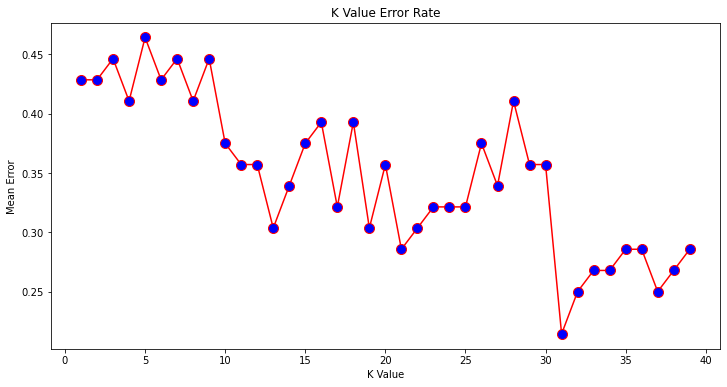

```python
plt.figure(figsize=(12,6))
plt.plot(range(1, 40), error, color='red', marker='o', markerfacecolor='blue', markersize = 10)
plt.title('K Value Error Rate')
plt.xlabel('K Value')
plt.ylabel('Mean Error')
#Below plot representing error rates for different K values.
```

### 10-fold Cross-Validation for KNN

```python
from sklearn.model_selection import cross_val_score
scores = cross_val_score(classifier, X, y, cv=10)
print("Accuracy for 10-fold Cross-Validation is:", scores.mean())
print("Error for 10-fold Cross-Validation is:", 1-scores.mean())
```

```
Accuracy for 10-fold Cross-Validation is: 0.4472527472527473
Error for 10-fold Cross-Validation is: 0.5527472527472528
```

### Naive Bayes Algorithm

```python
from sklearn.naive_bayes import GaussianNB
```

```python
classifier = GaussianNB()
classifier.fit(X_train, y_train) #algorithm application
```

```
GaussianNB()
```

```python
y_pred = classifier.predict(X_test)
y_pred #displaying predicted values
```

```
array([0, 0, 0, 0, 0, 1, 1, 1, 1, 0, 1, 0, 1, 0, 0, 1, 1, 0, 0, 1, 0, 0,
       0, 1, 0, 0, 0, 0, 0, 1, 0, 1, 0, 1, 0, 0, 0, 1, 0, 0, 0, 1, 1, 0,
       0, 1, 1, 0, 1, 0, 1, 0, 1, 1, 0, 1], dtype=int64)
```

```python
from sklearn.metrics import confusion_matrix, accuracy_score
cm = confusion_matrix(y_test, y_pred)
ac = accuracy_score(y_test, y_pred)
print("Accuracy =", ac)
print("Error =", 1-ac)
print("matrix_confusion = \n", cm)
```

```
Accuracy = 0.5714285714285714
Error = 0.4285714285714286
matrix_confusion =
 [[17  8]
 [16 15]]
```

### 10-Fold Cross-Validation for Naive Bayes

```python
scores = cross_val_score(classifier, X, y, cv=10)
print("Accuracy for 10-fold Cross-Validation is:", scores.mean())
print("Error for 10-fold Cross-Validation is:", 1-scores.mean())
```

```
Accuracy for 10-fold Cross-Validation is: 0.5857142857142857
Error for 10-fold Cross-Validation is: 0.41428571428571426
```